# TUGAS 2 ANREG

# A. Deskripsi Data

Metode: Saya menggunakan data sekunder hasil scraping dari Yahoo Finance yang berisi rasio keuangan berbagai emiten.

## A.1. Input Data

```r
data<-read.csv2("C:\\Users\\a c e r\\OneDrive\\SEMESTER 4\\ANALISIS REGRESI\\DATA ANREG PRAK\\DATA USING FOR R.csv")
```

## A.2. Sumber Data

Saya menggunakan data sekunder hasil scraping dari Yahoo Finance yang berisi rasio keuangan berbagai emiten. Data yang saya gunakan terdiri dari 170 observasi yang saya dapatkan secara acak.

## A.3. Deskripsi Variabel

1. NPM_Y: Net Profit Margin, margin laba bersih perusahaan.
2. GPM_X1: Gross Profit Margin.
3. OPM_X2: Operating Profit Margin.
4. ROA_X5: Return on Asset.
5. ROE_X6: Return on Equity.
6. CurrRatio_X7: Rasio Likuiditas
7. DER_X13: Rasio Solvabilitas

## A.4. Statistika Deskriptif

```r
summary_data <- summary(data[, 2:8])
print(summary_data)
```

```
##      NPM_Y              GPM_X1             OPM_X2             ROA_X5
##  Min.   :-0.18132   Min.   :-0.07754   Min.   :-0.18274   Min.   :-0.06475
##  1st Qu.: 0.03614   1st Qu.: 0.16619   1st Qu.: 0.05946   1st Qu.: 0.02164
##  Median : 0.09563   Median : 0.29164   Median : 0.12401   Median : 0.04820
##  Mean   : 0.12276   Mean   : 0.33487   Mean   : 0.15431   Mean   : 0.05438
##  3rd Qu.: 0.18112   3rd Qu.: 0.45855   3rd Qu.: 0.22092   3rd Qu.: 0.07923
##  Max.   : 0.39859   Max.   : 0.89708   Max.   : 0.46311   Max.   : 0.16563
##      ROE_X6          CurrRatio_X7      DER_X13
##  Min.   :-0.15904   Min.   :0.158   Min.   :  0.003
##  1st Qu.: 0.04215   1st Qu.:1.243   1st Qu.:  4.588
##  Median : 0.09018   Median :2.075   Median : 26.453
##  Mean   : 0.11899   Mean   :2.748   Mean   : 40.638
##  3rd Qu.: 0.17628   3rd Qu.:3.509   3rd Qu.: 56.737
##  Max.   : 0.37748   Max.   :6.908   Max.   :134.960
```

## A.5. Visualisasi Deskriptif

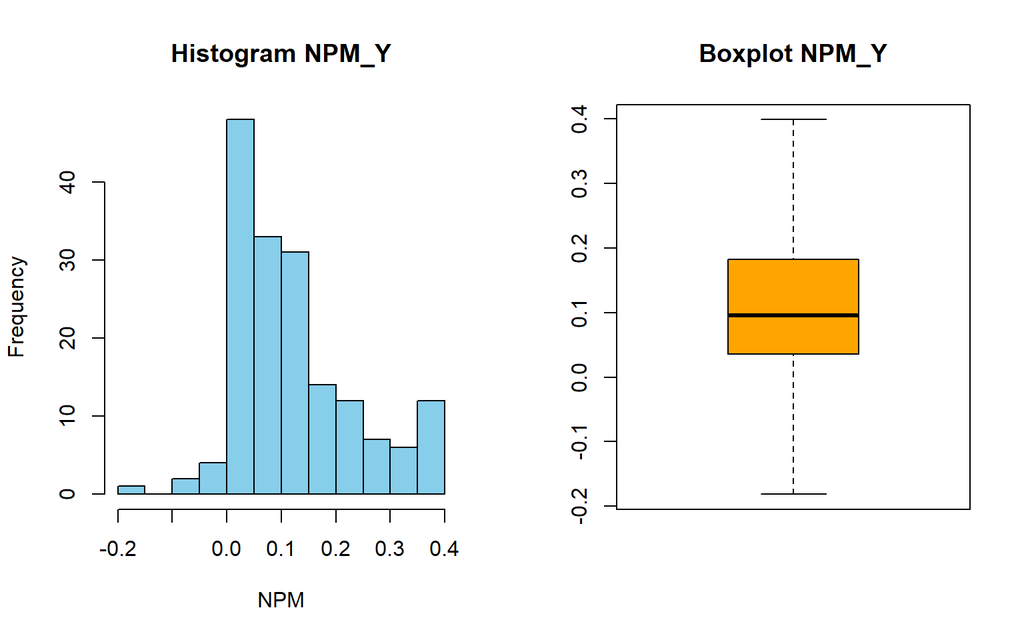

```r
par(mfrow=c(1,2))
hist(data$NPM_Y, col="skyblue", main="Histogram NPM_Y", xlab="NPM")
boxplot(data$NPM_Y, col="orange", main="Boxplot NPM_Y")
```

# B. Eksplorasi Data

Metode: Saya menggunakan matriks korelasi dan scatter plot untuk melihat hubungan linier awal.

## B.1. Matrix Korelasi

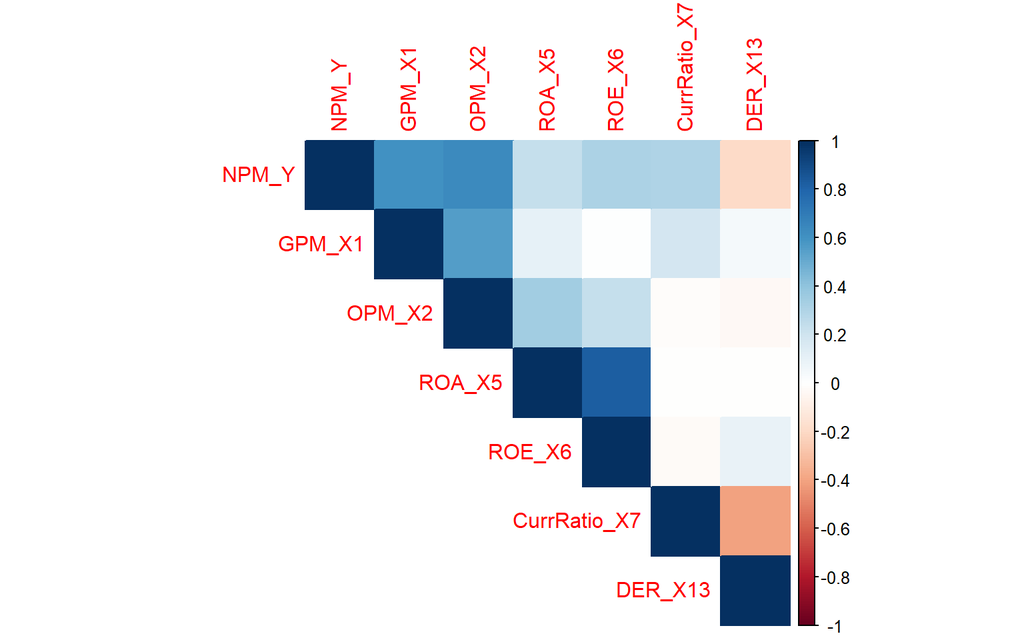

```r
library(corrplot)
cor_matrix <- cor(data[,-1])
corrplot(cor_matrix, method = "color", type = "upper")
```

## B.2. Scatter Plot masing-masing X

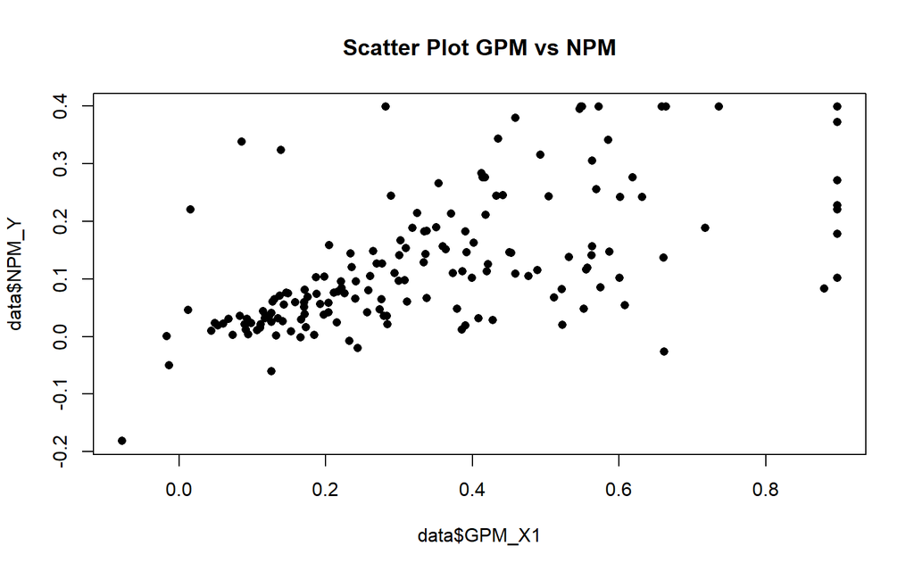

```r
plot(data$GPM_X1, data$NPM_Y, main="Scatter Plot GPM vs NPM", pch=16)
```

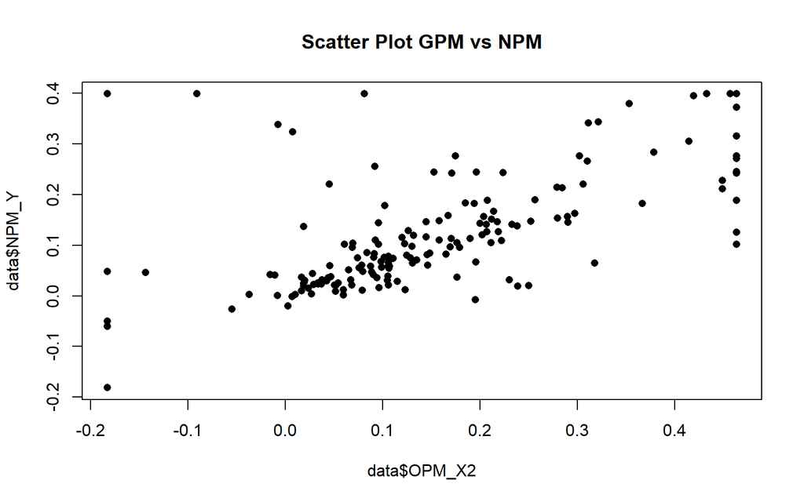

```r
plot(data$OPM_X2, data$NPM_Y, main="Scatter Plot GPM vs NPM", pch=16)
```

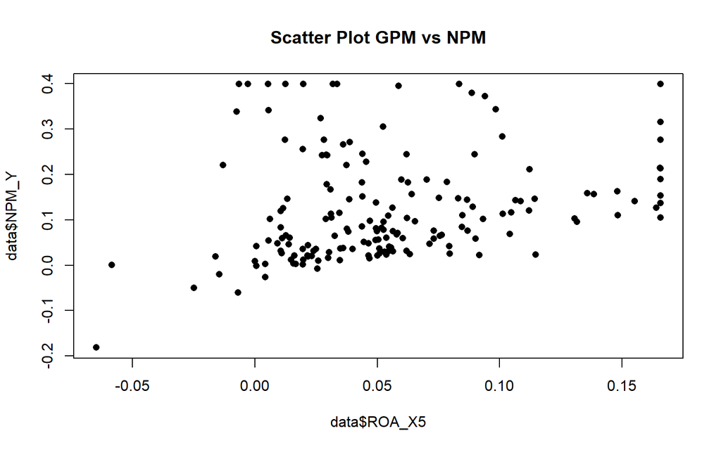

```r
plot(data$ROA_X5, data$NPM_Y, main="Scatter Plot GPM vs NPM", pch=16)
```

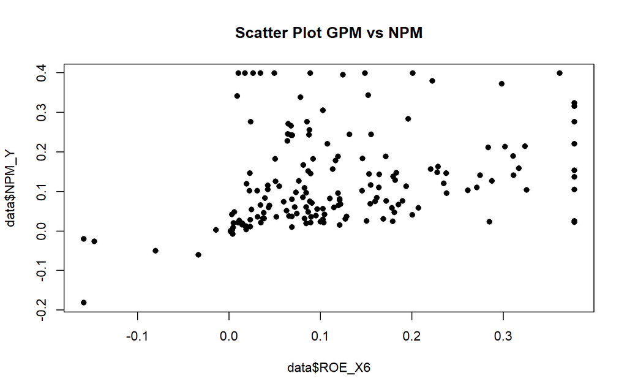

```r
plot(data$ROE_X6, data$NPM_Y, main="Scatter Plot GPM vs NPM", pch=16)
```

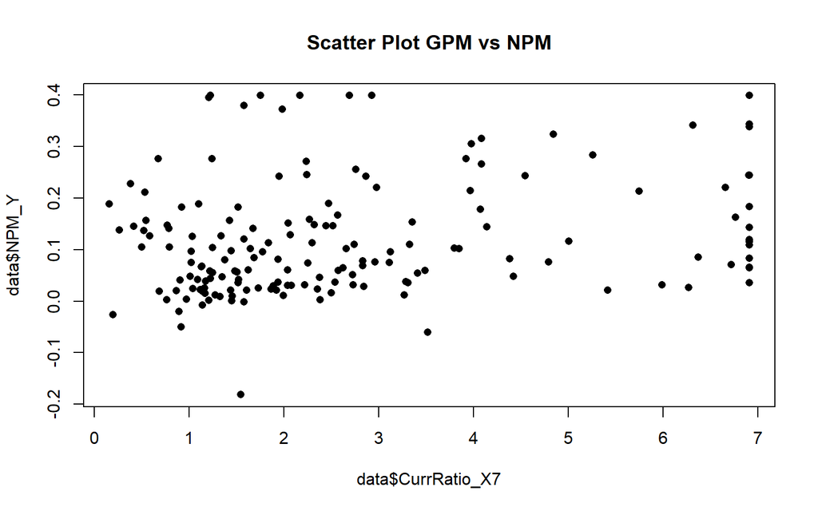

```r
plot(data$CurrRatio_X7, data$NPM_Y, main="Scatter Plot GPM vs NPM", pch=16)
```

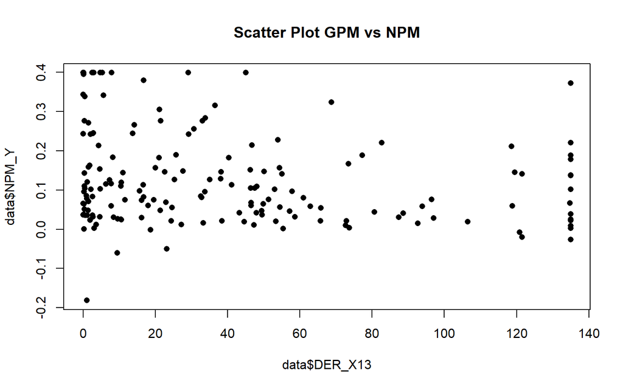

```r
plot(data$DER_X13, data$NPM_Y, main="Scatter Plot GPM vs NPM", pch=16)
```

## B.3. Interpretasi

Saya mengamati bahwa GPM, OPM, ROA, dan ROE cenderung memiliki hubungan positif dengan NPM. DER kemungkinan memiliki hubungan negatif.

# C. Pemodelan Regresi

Metode: Saya membentuk model menggunakan fungsi lm() di R.

## C.1. Model Regresi

```r
model <- lm(NPM_Y ~ GPM_X1 + OPM_X2 + ROA_X5 + ROE_X6 + CurrRatio_X7 + DER_X13, data = data)
summary(model)
```

```
##
## Call:
## lm(formula = NPM_Y ~ GPM_X1 + OPM_X2 + ROA_X5 + ROE_X6 + CurrRatio_X7 +
##     DER_X13, data = data)
##
## Residuals:
##       Min        1Q    Median        3Q       Max
## -0.190481 -0.036879 -0.004817  0.028438  0.284081
##
## Coefficients:
##                Estimate Std. Error t value Pr(>|t|)
## (Intercept)  -0.0201755  0.0143001  -1.411 0.160191
## GPM_X1        0.2030813  0.0293015   6.931 9.26e-11 ***
## OPM_X2        0.3374468  0.0442438   7.627 1.89e-12 ***
## ROA_X5       -1.1805581  0.2005783  -5.886 2.19e-08 ***
## ROE_X6        0.6628448  0.0837587   7.914 3.62e-13 ***
## CurrRatio_X7  0.0104320  0.0029171   3.576 0.000459 ***
## DER_X13      -0.0005041  0.0001351  -3.730 0.000264 ***
## ---
## Signif. codes:  0 '***' 0.001 '**' 0.01 '*' 0.05 '.' 0.1 ' ' 1
##
## Residual standard error: 0.06547 on 163 degrees of freedom
## Multiple R-squared:  0.6916, Adjusted R-squared:  0.6802
## F-statistic: 60.92 on 6 and 163 DF,  p-value: < 2.2e-16
```

## C.2. Persamaan Model

Berdasarkan hasil estimasi, saya memperoleh model regresi sebagai berikut:

$NPM^ = −0.0202 + 0.2031GPM + 0.3374OPM − 1.1806ROA + 0.6628ROE + 0.0104CurrRatio − 0.000504DER$

## C.3. Interpretasi

1. Intercept (-0.0202). Ketika semua variabel prediktor bernilai 0, maka nilai NPM diperkirakan sebesar -0.0202.
2. GPM (0.2031). Setiap kenaikan 1 unit GPM akan meningkatkan NPM sebesar 0.2031, dengan asumsi variabel lain konstan.
3. OPM (0.3374). Setiap kenaikan 1 unit OPM akan meningkatkan NPM sebesar 0.3374.
4. ROA (-1.1806). Setiap kenaikan 1 unit ROA justru menurunkan NPM sebesar 1.1806.
5. ROE (0.6628). Setiap kenaikan 1 unit ROE meningkatkan NPM sebesar 0.6628.
6. Current Ratio (0.0104). Pengaruhnya positif tetapi SANGAT kecil HUFTY.
7. DER (-0.000504). Setiap kenaikan DER menurunkan NPM, artinya semakin tinggi utang relatif, profitabilitas menurun.

# D. Pengujian Hipotesis Parameter

Metode: Saya menguji hipotesis dengan menggunakan uji t Parsial.

## D.1. Statistik Uji Hipotesis Parsial

```r
model <- lm(NPM_Y ~ GPM_X1 + OPM_X2 + ROA_X5 + ROE_X6 + CurrRatio_X7 + DER_X13, data = data)
summary(model)$coefficients
```

```
##                   Estimate   Std. Error   t value     Pr(>|t|)
## (Intercept)  -0.0201755237 0.0143001431 -1.410862 1.601911e-01
## GPM_X1        0.2030813274 0.0293015238  6.930743 9.256044e-11
## OPM_X2        0.3374467879 0.0442437937  7.626986 1.888247e-12
## ROA_X5       -1.1805580943 0.2005783388 -5.885771 2.191698e-08
## ROE_X6        0.6628448191 0.0837586741  7.913745 3.620360e-13
## CurrRatio_X7  0.0104320459 0.0029170913  3.576181 4.591480e-04
## DER_X13      -0.0005040615 0.0001351238 -3.730368 2.635999e-04
```

## D.2. Uji Hipotesis Parsial NPM

$H_0: \beta_1 = 0$ (Secara parsial, Gross Profit Margin tidak berpengaruh signifikan terhadap Net Profit Margin).

$H_1: \beta_1 \neq 0$ (Secara parsial, Gross Profit Margin berpengaruh signifikan terhadap Net Profit Margin).

Karena p-value = $9.256044e-11$ < alpha = $0,05$, maka tolak H0. Berarti GPM berpengaruh signifikan terhadap NPM.

## D.3. Uji Hipotesis Parsial OPM

$H_0: \beta_2 = 0$ (Secara parsial, Operating Profit Margin tidak berpengaruh signifikan terhadap Net Profit Margin).

$H_1: \beta_2 \neq 0$ (Secara parsial, Operating Profit Margin berpengaruh signifikan terhadap Net Profit Margin).

Karena p-value = $1.888247e-12$ < alpha = $0,05$, maka tolak H0. Berarti OPM berpengaruh signifikan terhadap NPM.

## D.4. Uji Hipotesis Parsial ROA

$H_0: \beta_5 = 0$ (Secara parsial, Return on Asset tidak berpengaruh signifikan terhadap Net Profit Margin).

$H_1: \beta_5 \neq 0$ (Secara parsial, Return on Asset berpengaruh signifikan terhadap Net Profit Margin).

Karena p-value = $2.191698e-08$ < alpha = $0,05$, maka tolak H0. Berarti ROA berpengaruh signifikan terhadap NPM.

## D.5. Uji Hipotesis Parsial ROE

$H_0: \beta_6 = 0$ (Secara parsial, Return on Equity tidak berpengaruh signifikan terhadap Net Profit Margin).

$H_1: \beta_6 \neq 0$ (Secara parsial, Return on Equity berpengaruh signifikan terhadap Net Profit Margin).

Karena p-value = $3.620360e-13$ < alpha = $0,05$, maka tolak H0. Berarti ROE berpengaruh signifikan terhadap NPM.

## D.6. Uji Hipotesis Parsial CurrRatio

$H_0: \beta_7 = 0$ (Secara parsial, Current Ratio tidak berpengaruh signifikan terhadap Net Profit Margin).

$H_1: \beta_7 \neq 0$ (Secara parsial, Current Ratio berpengaruh signifikan terhadap Net Profit Margin).

Karena p-value = $4.591480e-04$ < alpha = $0,05$, maka tolak H0. Berarti CurrRatio berpengaruh signifikan terhadap NPM.

## D.7. Uji Hipotesis Parsial DER

$H_0: \beta_{13} = 0$ (Secara parsial, Debt to Equity Ratio tidak berpengaruh signifikan terhadap Net Profit Margin).

$H_1: \beta_{13} \neq 0$ (Secara parsial, Debt to Equity Ratio berpengaruh signifikan terhadap Net Profit Margin).

Karena p-value = $2.635999e-04$ < alpha = $0,05$, maka tolak H0. Berarti DER berpengaruh signifikan terhadap NPM.

## D.8. Interpretasi Keseluruhan

Berdasarkan hasil yang saya peroleh, seluruh variabel prediktor memiliki p-value yang lebih kecil dari $0,05$. Oleh karena itu, saya menyimpulkan untuk menolak $H_0$ bagi semua variabel, yang berarti seluruh variabel independen dalam model ini memiliki pengaruh nyata terhadap NPM_Y.

# E. Diagnostik Regresi

Metode: Saya melakukan cek asumsi untuk memastika validitas model

```r
library(car)
library(lmtest)
```

## E.1. Uji Normalitas Residual (Shapiro-Wilk)

```r
shapiro.test(residuals(model))
```

```
##
##  Shapiro-Wilk normality test
##
## data:  residuals(model)
## W = 0.9626, p-value = 0.0001585
```

## E.2. Uji Homoskedastisitas (Breusch Pagan)

```r
bptest(model)
```

```
##
##  studentized Breusch-Pagan test
##
## data:  model
## BP = 44.27, df = 6, p-value = 6.536e-08
```

## E.3. Uji Independensi Residual (Uji Durbin-Watson)

```r
dwtest(model)
```

```
##
##  Durbin-Watson test
##
## data:  model
## DW = 1.7899, p-value = 0.08728
## alternative hypothesis: true autocorrelation is greater than 0
```

Berdasarkan uji Durbin-Watson, didapatkan nilai DW sebesar 1.7899, berarti tidak terjadi autokorelasi yang parah, sehingga asumsi independensi residual relatif terpenuhi.

## E.4. Uji Multikolinearitas (VIF)

```r
vif(model)
```

```
##       GPM_X1       OPM_X2       ROA_X5       ROE_X6 CurrRatio_X7      DER_X13
##     1.647669     1.718986     3.465756     3.331961     1.316183     1.296828
```

Berdasarkan nilai VIF masing-masing variabel, nilai VIF menunjukkan angka kurang dari 10. Itu berarti tidak terdapat multikolinearitas antar variabel prediktor.

## E.5. Outlier, Leverage, dan Amatan Berpengaruh

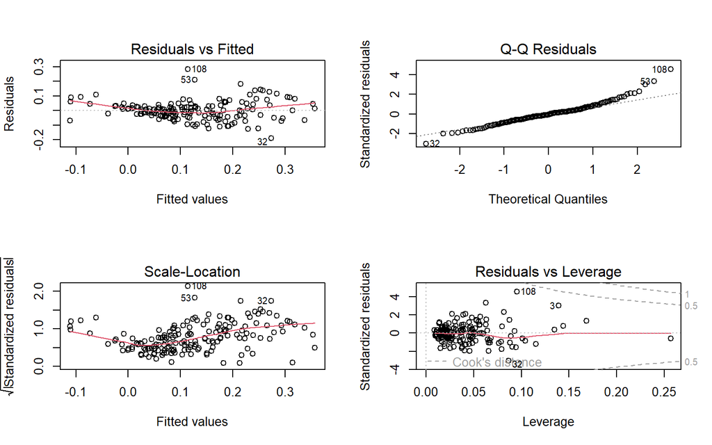

```r
par(mfrow=c(2,2))
plot(model)
```

# F. Interpretasi Hasil Diagnostik

Terdapat beberapa pelanggaran asumsi sesuai dengan yang sudah saya jelaskan diatas. Data yang saya gunakan tidak memenuhi asumsi residual menyebar normal dan varian residual tidak homogen.

Seharusnya diperlukan transformasi data terlebih dahulu untuk menangani masalah asumsi yang tidak terpenuhi.

# G. Kesimpulan

```r
summary(model)$r.squared
```

```
## [1] 0.6915746
```

```r
summary(model)$adj.r.squared
```

```
## [1] 0.6802215
```